# 자연언어처리 5주차_텍스트 마이닝을 사용한 자연언어처리 #2: 텍스트 전처리 및 감성분석

고려대학교 일반대학원 심리학과

2025년 9월 29일 월요일 4-5교시

# 0. 본 수업에 사용될 함수 미리보기

- 수업목표와 직접적으로 관련된 함수는 본문에서 상세히 소개.
- 함수의 상세한 사용법은 코드 주석을 참조.

**[표 1] 본 수업에 사용될 함수 목록**

| 함수 | 출처 패키지 | 기능 |
| --- | --- | --- |
| abs() | base R | 숫자의 절댓값 계산 |
| anti_join() | tidyverse(dplyr) | 두 데이터프레임을 비교해 왼쪽 테이블에만 있고 오른쪽 테이블에는 없는 행만 골라냄 |
| arrange() | tidyverse(dplyr) | 열 기준으로 정렬 |
| bind_rows() | tidyverse(dplyr) | 여러 데이터프레임을 행 기준으로 결합 |
| case_when() | tidyverse(dplyr) | 조건에 따라 값을 반환하는 다중 if-else 구조 |
| distinct() | tidyverse(dplyr) | 중복된 행 제거 |
| drop_na() | tidyverse(tidyr) | 결측값이 있는 행 제거 |
| group_by() | tidyverse(dplyr) | 특정 변수 기준으로 그룹화 |
| group_split() | tidyverse(dplyr) | 그룹별로 리스트 형태로 분리 |
| left_join() | tidyverse(dplyr) | 두 데이터프레임 병합 시 왼쪽 테이블 기준으로 오른쪽 테이블에서 일치하는 행의 정보를 붙여줌 |
| map_chr() | tidyverse(purrr) | 각 원소를 문자형으로 변환 |
| pivot_wider() | tidyverse(tidyr) | 긴 형식을 넓은 형식으로 변환 |
| possibly() | tidyverse(purrr) | 에러 발생 시 기본값 반환하는 안전한 함수 래퍼(wrapper: 다른 함수나 기능을 감싸는 함수) |
| pull() | tidyverse(dplyr) | 특정 열을 벡터로 추출 |
| separate() | tidyverse(tidyr) | 하나의 열을 여러 열로 분리 |
| slice_max() | tidyverse(dplyr) | 특정 열 기준으로 상위 n개 추출 |
| str_remove_all() | tidyverse(stringr) | 문자열에서 특정 패턴 모두 제거 |
| summarise() | tidyverse(dplyr) | 그룹별 요약 통계 계산 |
| ungroup() | tidyverse(dplyr) | 그룹 구조 제거 |
| unnest() | tidyverse(tidyr) | 리스트 형태의 열을 행으로 펼침 |

# 1. tidy 텍스트 형식 다루기

## (1) tidy 텍스트의 이해

- tidy 데이터: 개별 변수가 열이 되고, 개별 관찰값이 행을 차지하는 형식의 데이터.
- tidy 텍스트
  - 정의: 하나의 토큰이 하나의 행을 차지하는 형식의 테이블.
  - 토큰(token)
    - 텍스트를 구성하는 유의미한 단위. 분석을 위해 사용하고자 하는 단위([EX] 단어, n-그램, 문장, 단락, 문서 등).
    - 대개는 단어가 이에 해당. 토큰화(tokenization) 를 통해 텍스트를 토큰 단위로 분절하는 절차를 거침.
    - **tidytext** 패키지를 통해 원하는 단위로 토큰화 가능.
  - 특징
    - tidy 데이터셋이므로 **tidyverse**에 속한 패키지들 사용 가능.
    - `tidy()` 함수를 사용하여 **tm**, **quanteda** 같은 다른 텍스트 마이닝 패키지의 객체 또한 tidy 형식으로 변환 가능. 그러나 이번 수업에서는 **tm**, **quanteda** 패키지는 다루지 않음.

## (2) `unnest_tokens` 함수

### 1) 예시

- 기능: 티블 형식의 텍스트를 토큰화해주는 함수.
- `text_tb`은 tidy 텍스트인가?
  - 현진건의 단편소설 **17원 50전(十七圓五十錢): 젋은 화가 A의 눈물 한 방울** 중 일부를 벡터화 $\rightarrow$ 티블화.
  - 아직 단어 단위 분석은 불가능. 단어 단위로 토큰화(한 행에 한 단어 할당)하지 않았기 때문.

```r
library(tidyverse)

# 현진건의 단편소설 중 일부를 벡터로 저장하기.
text_vec <- c("NC의 눈에서는 여태까지 보지 못하던 눈물이 흘렀습니다.",
              "NC의 가슴은 에이고 애탄의 결정인 뜨거운 눈물은 차디찬 옷깃을 적시고 식어 버리더이다.",
              "바다에는 진주가 있습니다." ,
              "우리 사람에게는 뜨겁게 반짝이는 눈물이 있습니다." ,
              "누가 이것을 보고 울지 않는 이가 있고 누가 이 꼴을 보고 눈물 홀리지 않는 이가 있을까요?"
)
text_vec
```

```
## [1] "NC의 눈에서는 여태까지 보지 못하던 눈물이 흘렀습니다."
## [2] "NC의 가슴은 에이고 애탄의 결정인 뜨거운 눈물은 차디찬 옷깃을 적시고 식어 버리더이다."
## [3] "바다에는 진주가 있습니다."
## [4] "우리 사람에게는 뜨겁게 반짝이는 눈물이 있습니다."
## [5] "누가 이것을 보고 울지 않는 이가 있고 누가 이 꼴을 보고 눈물 홀리지 않는 이가 있을까요?"
```

```r
# text_vec을 티블로 변환히기.
text_tb <- tibble(line = 1:5, text = text_vec)
text_tb
```

```
## # A tibble: 5 × 2
##    line
##   <int>
## 1     1
## 2     2
## 3     3
## 4     4
## 5     5
##   text
##   <chr>
## 1 NC의 눈에서는 여태까지 보지 못하던 눈물이 흘렀습니다.
## 2 NC의 가슴은 에이고 애탄의 결정인 뜨거운 눈물은 차디찬 옷깃을 적시고 식어 버리더이다.……
## 3 바다에는 진주가 있습니다.
## 4 우리 사람에게는 뜨겁게 반짝이는 눈물이 있습니다.
## 5 누가 이것을 보고 울지 않는 이가 있고 누가 이 꼴을 보고 눈물 홀리지 않는 이가 있을까요?……
```

### 2) 논항 1: `token`

- `input`: 토큰화를 위해 투입되는 텍스트 입력 열.
- `output`: 토큰화 이후의 출력 열.
- `token`: 토큰화의 유형. `"words"`를 택하면 단어(띄어쓰기) 단위로 토큰화됨.

#### A. 단일 단어

- 단어 단위로 토큰화하기: `token` 논항으로 `"words"` 입력.

```r
library(tidytext)

# 단어 단위로 토큰화하기.
text_tb %>%
  unnest_tokens(output = word, input = text, token = "words")
```

```
## # A tibble: 46 × 2
##     line word
##    <int> <chr>
##  1     1 nc
##  2     1 의
##  3     1 눈에서는
##  4     1 여태까지
##  5     1 보지
##  6     1 못하던
##  7     1 눈물이
##  8     1 흘렀습니다
##  9     2 nc
## 10     2 의
## # ℹ 36 more rows
```

#### B. 단일 문장

```r
# 문장 단위로 토큰화하기.
text_tb %>%
  unnest_tokens(output = word, input = text, token = "sentences")
```

```
## # A tibble: 5 × 2
##    line
##   <int>
## 1     1
## 2     2
## 3     3
## 4     4
## 5     5
##   word
##   <chr>
## 1 nc의 눈에서는 여태까지 보지 못하던 눈물이 흘렀습니다.
## 2 nc의 가슴은 에이고 애탄의 결정인 뜨거운 눈물은 차디찬 옷깃을 적시고 식어 버리더이다.……
## 3 바다에는 진주가 있습니다.
## 4 우리 사람에게는 뜨겁게 반짝이는 눈물이 있습니다.
## 5 누가 이것을 보고 울지 않는 이가 있고 누가 이 꼴을 보고 눈물 홀리지 않는 이가 있을까요?……
```

#### C. n-그램

- n-그램 단위로 토큰화하기: `token` 논항으로 `"ngrams"` 입력.

```r
# 바이그램 단위로 토큰화하기.
text_tb %>%
  unnest_tokens(output = word, input = text, token = "ngrams", n = 2)
```

```
## # A tibble: 41 × 2
##     line word
##    <int> <chr>
##  1     1 nc 의
##  2     1 의 눈에서는
##  3     1 눈에서는 여태까지
##  4     1 여태까지 보지
##  5     1 보지 못하던
##  6     1 못하던 눈물이
##  7     1 눈물이 흘렀습니다
##  8     2 nc 의
##  9     2 의 가슴은
## 10     2 가슴은 에이고
## # ℹ 31 more rows
```

#### D. 단일 글자/음절

- 단일 글자/음절 단위로 토큰화하기
  - `token` 논항으로 `"characters"` 입력.
  - 영어는 글자 단위, 한국어는 음절 단위로 토큰화됨.

```r
# 단일 글자/음절 단위로 토큰화한 뒤 토큰의 빈도 분석하기.
text_tb %>%
  unnest_tokens(output = word, input = text, token = "characters") %>%
  count(word, sort = T)
```

```
## # A tibble: 65 × 2
##    word      n
##    <chr> <int>
##  1 이        9
##  2 가        6
##  3 는        6
##  4 고        5
##  5 눈        5
##  6 다        5
##  7 물        4
##  8 에        4
##  9 을        4
## 10 있        4
## # ℹ 55 more rows
```

#### E. 여러 글자/음절

- 여러 글자/음절 단위로 토큰화하기
  - `token` 논항으로 `"character_shingles"` 입력.
  - 영어는 글자 단위, 한국어는 음절 단위로 토큰화됨.

```r
# 두 글자/음절 단위로 토큰화한 뒤 토큰의 빈도 분석하기.
text_tb %>%
  unnest_tokens(output = word, input = text, token = "character_shingles", n = 2) %>%
  count(word, sort = T)
```

```
## # A tibble: 102 × 2
##    word      n
##    <chr> <int>
##  1 눈물      4
##  2 가있      3
##  3 니다      3
##  4 습니      3
##  5 c의       2
##  6 nc        2
##  7 가이      2
##  8 누가      2
##  9 는이      2
## 10 물이      2
## # ℹ 92 more rows
```

#### F. 정규표현식

- 정규표현식을 사용하여 사용자가 원하는 단위로 토큰화하기
  - `token` 논항으로 `"regex"` 입력
  - `pattern` 논항으로 원하는 정규표현식 입력.

```r
# 개행 "\n" 단위로 토큰화하기.
text_tb %>%
  unnest_tokens(output = word, input = text, token = "regex", pattern = "\n")
```

```
## # A tibble: 5 × 2
##    line
##   <int>
## 1     1
## 2     2
## 3     3
## 4     4
## 5     5
##   word
##   <chr>
## 1 nc의 눈에서는 여태까지 보지 못하던 눈물이 흘렀습니다.
## 2 nc의 가슴은 에이고 애탄의 결정인 뜨거운 눈물은 차디찬 옷깃을 적시고 식어 버리더이다.……
## 3 바다에는 진주가 있습니다.
## 4 우리 사람에게는 뜨겁게 반짝이는 눈물이 있습니다.
## 5 누가 이것을 보고 울지 않는 이가 있고 누가 이 꼴을 보고 눈물 홀리지 않는 이가 있을까요?……
```

```r
# "+" 단위로 토큰화하기.
text_tb %>%
  mutate(text = str_replace_all(text, " ", "+")) %>%
  unnest_tokens(output = word, input = text, token = "regex", pattern = "\\+")
```

```
## # A tibble: 44 × 2
##     line word
##    <int> <chr>
##  1     1 nc의
##  2     1 눈에서는
##  3     1 여태까지
##  4     1 보지
##  5     1 못하던
##  6     1 눈물이
##  7     1 흘렀습니다.
##  8     2 nc의
##  9     2 가슴은
## 10     2 에이고
## # ℹ 34 more rows
```

### 3) 논항 2: `to_lower`

- 영문 알파벳 대문자의 소문자화 여부를 결정하는 논항
  - 기본값: `to_lower = TRUE`.
  - `FALSE`로 지정 시 대문자를 소문자로 변경하지 않음. 인명이나 지명 같은 고유명사 구분 필요 시 `FALSE`로 지정할 것.

```r
# 영문 알파벳 대문자를 소문자로 변경하지 않기.
text_tb %>%
  unnest_tokens(output = word, input = text, token = "words", to_lower = FALSE)
```

```
## # A tibble: 46 × 2
##     line word
##    <int> <chr>
##  1     1 NC
##  2     1 의
##  3     1 눈에서는
##  4     1 여태까지
##  5     1 보지
##  6     1 못하던
##  7     1 눈물이
##  8     1 흘렀습니다
##  9     2 NC
## 10     2 의
## # ℹ 36 more rows
```

### 4) 논항 3: `strip_punct`

- 문장부호 제거 여부 결정: `TRUE` 설정 시 문장부호 제거.

```r
# 문장부호 제거한 경우.
text_tb %>%
  unnest_tokens(output = word, input = text, token = "words", strip_punct = TRUE)
```

```
## # A tibble: 46 × 2
##     line word
##    <int> <chr>
##  1     1 nc
##  2     1 의
##  3     1 눈에서는
##  4     1 여태까지
##  5     1 보지
##  6     1 못하던
##  7     1 눈물이
##  8     1 흘렀습니다
##  9     2 nc
## 10     2 의
## # ℹ 36 more rows
```

```r
# 문장부호 제거하지 않은 경우.
text_tb %>%
  unnest_tokens(output = word, input = text, token = "words", strip_punct = FALSE)
```

```
## # A tibble: 51 × 2
##     line word
##    <int> <chr>
##  1     1 nc
##  2     1 의
##  3     1 눈에서는
##  4     1 여태까지
##  5     1 보지
##  6     1 못하던
##  7     1 눈물이
##  8     1 흘렀습니다
##  9     1 .
## 10     2 nc
## # ℹ 41 more rows
```

## (3) 정규화(normalization)하기

- 정의: 추출된 단어를 일정한 형식으로 규격화화는 절차.
- 의의
  - “마시다”는 다양한 활용형([EX]“마셔서”, “마셨군”, “마실”)를 지님. 다양한 활용형이 같은 의미를 나타낸다면 정규화를 통해 일정한 형식으로 규격화하는 작업이 필요.
  - 정규화가 제대로 되지 않으면 해당 텍스트 사전의 규모가 지나치게 방대해지고, 어미나 조사 같은 불필요한 토큰이 포함되어 분석에 부하를 줄 수 있음.
- 대표적인 종류
  - 단어(word): 자립이 가능한 최소 언어단위. [EX] 책상, 먹었다.
  - 형태소(morpheme): 의미 또는 기능을 지닌 최소 언어단위. [EX] 먹(어간) + 었(선어말어미) + 다(종결어미) + .(마침표 기호)

### 1) 단어 단위

- 한국어의 경우, 기존 띄어쓰기(어절) 단위에 해당.

### 2) 형태소 단위

- 시중의 형태소 분석기들이 가장 많이 참조하는 품사분류 체계: [해당 웹페이지](https://docs.komoran.kr/firststep/postypes.html) 참조.

#### A. **RcppMeCab**으로 형태소 분석하기

- **RcppMeCab** 패키지의 `pos` 함수를 **tidytex** 패키지의 `token` 논항에 넣어 토큰화의 한 방법으로 활용 가능: **RcppMeCab**으로 분석된 형태소가 토큰화의 단위가 됨.
- 설치 시 필수조건: **MeCab** 응용 프로그램을 C 드라이브에 설치해야 함. 설치방법(윈도우 사용자)은 [링크](https://wonhwa.tistory.com/49)를 참조할 것.
- 주의사항: **RcppMeCab**은 정확성과 속도는 우수한 편이나, 용언의 어간 + 어미를 물리적으로 분리해주지 않는다는 단점이 있음.
- 주요 함수
  - `pos` 함수
    - 개관
      - 기본 형태소 분석 함수. 문자열 벡터를 분석하여 형태소 태그를 부착해줌.
      - 장점: 띄어쓰기가 불완전해도 알아서 어절 단위로 분할해줌.
      - 단점: 용언 + 어미 어절은 형태소 태그를 부착해주나, 둘을 분해해주지는 않음.
    - 논항
      - `join = T`: 디폴트가 `TRUE`임. “형태소/품사” 형태로 결과 반환.
      - `format = data.frame`: 디폴트가 리스트임. 데이터 프레임 형식으로 결과 반환.
  - `posParrell` 함수
    - `pos`와 같은 기능을 수행하지만, 다중 스레딩(multi-threading: 여러 작업을 병렬로 처리)을 지원해줌.
    - 속도는 빠르나, 그만큼 메모리 소모도 많음.
    - 논항은 `pos`와 동일.

```r
library(RcppMeCab)

# sjml_result.rda 파일 다운로드하기.
sjml_url <- "https://github.com/cognitivepsychology/NLP_2025/raw/main/sjml_result.rda"
download.file(url = sjml_url,
              destfile = "sjml_result.rda",
              mode = "wb"
)

load("sjml_result.rda")

# 메타데이터 정보를 유지하면서 텍스트 정규화하기.
sjml.result.tagged.rcpp <- sjml_result[1:10, ] %>% # 메타데이터 정보가 포함된 XML 텍스트 티블.
  mutate(text = enc2utf8(text)) %>% # R 내장함수인 enc2utf8을 통해 text 열의 텍스트를 UTF-8 형식으로 인코딩하기(그래야 한글이 깨지지 않음!).
  unnest_tokens(morp, text, token = RcppMeCab::pos, to_lower = F) %>% # RcppMeCab 패키지의 pos 함수를 사용하여 토큰화. 이때 형태소 태깅이 대문자를 유지하도록 함.
  filter(!str_detect(morp, "J[A-Z]{1,3}|E[A-Z]{1,3}|S[A-Z]{1,3}")) %>%  # 조사([EX] JKS, JSO), 어미([EX] EF, EP), 기호([EX] SF, SP) 제외.
  separate(morp, sep = "/", into = c("morp_untagged", "pos")) # 형태소와 품사 태그를  "/"를 기준으로 분리하여 두 개의 칼럼 생성.
sjml.result.tagged.rcpp
```

```
## # A tibble: 2,873 × 9
##    title         category        author_age author_occupation author_sex
##    <chr>         <chr>                <dbl> <chr>             <chr>
##  1 아내의 생일상 비출판물 > 수필         45 직장인/전문직     M
##  2 아내의 생일상 비출판물 > 수필         45 직장인/전문직     M
##  3 아내의 생일상 비출판물 > 수필         45 직장인/전문직     M
##  4 아내의 생일상 비출판물 > 수필         45 직장인/전문직     M
##  5 아내의 생일상 비출판물 > 수필         45 직장인/전문직     M
##  6 아내의 생일상 비출판물 > 수필         45 직장인/전문직     M
##  7 아내의 생일상 비출판물 > 수필         45 직장인/전문직     M
##  8 아내의 생일상 비출판물 > 수필         45 직장인/전문직     M
##  9 아내의 생일상 비출판물 > 수필         45 직장인/전문직     M
## 10 아내의 생일상 비출판물 > 수필         45 직장인/전문직     M
##    author_submission author_handwriting morp_untagged pos
##    <chr>             <chr>              <chr>         <chr>
##  1 온라인            No                 어제          NNG
##  2 온라인            No                 아내          NNG
##  3 온라인            No                 생일          NNG
##  4 온라인            No                 이            VCP
##  5 온라인            No                 생일          NNG
##  6 온라인            No                 맞이          XR
##  7 온라인            No                 아침          NNG
##  8 온라인            No                 준비          NNG
##  9 온라인            No                 오전          NNG
## 10 온라인            No                 시            NNBC
## # ℹ 2,863 more rows
```

```r
# 메타데이터의 성별 정보가 남성 & 40대 이상인 경우의 텍스트만 사용하기(벡터로 저장할 경우)
sjml_result.morp <- sjml_result %>%
  mutate(text = enc2utf8(text)) %>%
  unnest_tokens(morp, text, token = RcppMeCab::pos, to_lower =F) %>%
  filter(!str_detect(morp, "J[A-Z]{1,3}|E[A-Z]{1,3}|S[A-Z]{1,3}")) %>%
  filter(author_sex == "M" & author_age >= 40) %>%
  pull(morp) # morp(형태소) 열만 벡터로 남기기.
sjml_result.morp[1:100]
```

```
##   [1] "어제/NNG"     "아내/NNG"     "생일/NNG"     "이/VCP"       "생일/NNG"
##   [6] "맞이/XR"      "아침/NNG"     "준비/NNG"     "오전/NNG"     "시/NNBC"
##  [11] "분/NNBC"      "음식/NNG"     "준비/NNG"     "메뉴/NNG"     "스테이크/NNG"
##  [16] "낙지볶음/NNG" "미역국/NNG"   "잡채/NNG"     "소야/NNG"     "등/NNB"
##  [21] "이/VCP"       "스테이크/NNG" "자주/MAG"     "하/VV"        "음식/NNG"
##  [26] "이/VCP"       "자신/NNG"     "준비/NNG"     "앞뒤/NNG"     "분/NNBC"
##  [31] "번/NNBC"      "뒤집/VV"      "레/NNP"       "스팅/NNP"     "잘/MAG"
##  [36] "하/VV"        "육즙/NNG"     "가득/MAG"     "스테이크/NNG" "준비/NNG"
##  [41] "아내/NNG"     "그런/MM"      "스테이크/NNG" "그런데/MAJ"   "상상/NNG"
##  [46] "일/NNG"       "벌이/VV"      "말/VX"        "보통/MAJ"     "시즈/NNP"
##  [51] "닝/NNP"       "되/VV"        "않/VX"        "원/NNG"       "육/NNG"
##  [56] "사/VV"        "스테이크/NNG" "이번/NNG"     "시즈/NNP"     "닝/NNP"
##  [61] "부채살/NNP"   "구입/NNG"     "그런데/MAJ"   "케이스/NNG"   "안/NNG"
##  [66] "방부제/NNG"   "들/VV"        "있/VX"        "것/NNB"       "인지/NNG"
##  [71] "못하/VX"      "방부제/NNG"   "동시/NNG"     "후라이팬/NNG" "올려놓/VV"
##  [76] "것/NNB"       "이/VCP"       "그것/NP"      "체/NNB"       "앞면/NNG"
##  [81] "센불/NNP"     "분/NNBC"      "굽/VV"        "뒤집/VV"      "순간/NNG"
##  [86] "방부제/NNG"   "함께/MAG"     "구/VV"        "것/NNB"       "알/VV"
##  [91] "아내/NNG"     "생일/NNG"     "이/VCP"       "맛있/VA"      "보/VX"
##  [96] "싶/VX"        "어처구니/NNG" "없/VA"        "상황/NNG"     "발생/NNG"
```

#### B. **bitNLP**으로 형태소 분석하기

```r
# remotes::install_github("bit2r/bitNLP") 미설치 시 R 서버가 아닌 깃허브에서 패키지를 다운받아 설치.
library(bitNLP)

test <- "나 어제 늦잠자서 수업에지각했당.. ㅜㅜ"
morpho_mecab(test, type = "morpheme")
```

```
##      NP     MAG     NNG     XSN     JKS     NNG     JKB     NNG  XSV+EP      EF
##    "나"  "어제"  "늦잠"    "자"    "서"  "수업"    "에"  "지각"    "했"    "당"
##      SF      SY UNKNOWN
##     "."     "."  "ㅜㅜ"
```

```r
# morpho_mecab 함수의 type 논항 디폴트가 명사(noun)이므로, 형태소(morpheme) 단위로 토큰화하려면 자체 제작 함수를 만들어야 함.
morpho_mecab_1 <- function(text, type = "morpheme"){
  result <- morpho_mecab(text, type = type) # morpho_mecab 함수를 사용하여 주어진 텍스트를 형태소 단위로 토큰화.
  str_c(as.character(result), "/", names(result), collapse = " ") # 형태소/품사태그([EX] "학교/NNG")의 형태로 토큰화. 벡터를 구성하는 개별 형태소([EX] "학교")에 부여된 명칭이 품사 태그([EX] "NNG")이므로, 이를 토큰화에 이용할 수 있음.
}

# 메타데이터 정보를 유지하면서 텍스트 정규화하기.
sjml_result.filtered <- sjml_result[1:10, ] %>%
  mutate(text_1 = map_chr(text, ~ morpho_mecab_1(.x))) %>% # 각 원소별로 함수를 적용해 문자열을 한 개씩 만듦 → 그 결과 한 줄의 문자형 벡터를 생성함.
  mutate(text_1 = map_chr(text_1, ~ {
    # 제거하고자 하는 품사 태그(기호, 어미, 조사)를 정규표현식으로 정의하기.
    pat <- "/(S|E|J)[A-Z]{1,3}"
    # 지정된 정규표현식에 해당하는 형태소만 str_remove_all 함수를 통해 제거하고 나머지 형태소만 취하기. str_remove_all()은 주어진 문자열에서 특정 패턴을 가진 부분을 제거하는 기능 수행.
    extracted_tags <- str_remove_all(.x, pattern = str_c("[^\\s]+", pat)) # "[^\\s]+"는 공백이 아닌 문자가 하나 이상 반복되는 것을 의미.
    # 추출된 결과에서 품사 태그 제거.
    extracted_tags_removed <- str_remove_all(unlist(extracted_tags), "/[A-Z]{1,5}+|\\+[A-Z]{1,5}") # str_remove_all()은 결과를 리스트로 반환하므로, unlist 함수를 사용해 결과를 벡터로 변환해야 함.
    # 추출된 결과에서 품사 태그 제거 후 공백(띄어쓰기 단위)으로 결합.
    str_c(extracted_tags_removed, collapse = " ") # extracted_tags_removed 벡터에 속한 각 요소(토큰!)를 공백(띄어쓰기 단위)으로 결합.
  }))
sjml_result.filtered
```

```
## # A tibble: 10 × 9
##    title                     category               author_age author_occupation
##    <chr>                     <chr>                       <dbl> <chr>
##  1 아내의 생일상             비출판물 > 수필                45 직장인/전문직
##  2 소금이 온다               비출판물 > 감상문               7 초등학생
##  3 졸업                      비출판물 > 일기                24 대학생/대학원생
##  4 감사일기                  비출판물 > 감상문              47 직장인/전문직
##  5 환경과 패스트패션         비출판물 > 기타 > 칼럼         44 직장인/전문직
##  6 58년 개띠                 비출판물 > 일기                61 전업주부
##  7 바이러스                  비출판물 > 수필                28 직장인/전문직
##  8 일하기싫다                비출판물 > 일기                27 직장인/전문직
##  9 힘들다는 것이 어떤 것인가 비출판물 > 수필                44 직장인/전문직
## 10 내  인생 영화, 세 얼간이  비출판물 > 감상문              45 직장인/전문직
##    author_sex author_submission author_handwriting
##    <chr>      <chr>             <chr>
```

[output cut: 34 more lines]

#### C. **kiwipiepy**로 형태소 분석하기

##### a. 소개 및 장단점

- 소개
  - 파이썬으로 작성된 한국어 형태소 분석기. 파이썬에서 직접 사용할 수 있어 편리하며, 특히 띄어쓰기 교정과 신조어 인식에 강점을 가지고 있음.
  - `tokenize` 함수: `form`(형태소), `tag`(품사), `start`(문자열에서의 위치), `len`(길이) 등의 정보를 제공.
  - `analyze` 함수
    - 설명: `form`(형태소), `tag`(품사), `start`(문자열에서의 위치), `len`(길이)와 함께 정확도 확률에 대한 로짓 제공. 로짓이 높을수록 해당 문자열의 품사가 정확히 분류되었을 가능성이 높음.
    - `top_n` 논항: 확률상 가능성이 높은 품사 목록을 여러 개 제시하도록 지정할 수 있음. “top_n = 3”이면 가장 가능성 높은 3개의 선택지를 제시하도록 할 수 있음.
- 장점
  - 뛰어난 속도: 분석속도가 빨라 대용량 데이터를 처리할 때 유리.
  - 쉬운 설치: 파이썬 환경에서 `pip install kiwipiepy` 명령어로 쉽게 설치 가능.
  - 신조어 및 미등록어 처리: 자체적으로 학습된 모델을 통해 새로운 단어나 오타를 어느 정도 처리 가능.
  - 사용자 정의 사전을 추가하여 정확도를 높일 수 있음.
- 단점
  - 비교적 낮은 정확도: **Mecab**에 비해 품사 태그의 종류가 적고, 일부 복합어 분리나 품사 태깅 정확도가 다소 떨어질 수 있음. 그러나 큰 차이 없으며, 학술용도로 사용하기에도 무방.
  - 개발 커뮤니티: **konlpy**나 **Mecab**에 비해 사용자층이 적어 정보공유나 문제해결이 상대적으로 어려울 수 있음(웬만하면 검색 대신 AI한테 물어보세요..).

##### b. R에서 이용하기 위한 절차

- 1단계: R에서 **reticulate** 패키지 설치 및 로드. R과 파이썬을 연결해주는 다리 역할을 하는 패키지.

```r
# reticulate 패키지 설치하기.
install.packages("reticulate")

# 패키지 로드하기.
library(reticulate)
```

- 2단계: 파이썬 가상환경 만들기
  - 가상환경 이름: 무엇으로 짓든 상관없음. 단, 하이픈이나 특수문자는 지양하는 게 좋음. 한 번만 생성하면 끝!
  - 파이썬 버전: 3.8이나 3.10 버전이 가장 안정적.
  - 설치용량: 기본적으로 Anaconda는 설치용량이 5GB 이상이고, R에서는 자동으로 C 드라이브에 설치함.
  - 수동설치 vs. R 설치: C 드라이브 용량이 충분치 않으면, 용량이 넉넉한 드라이브에 직접 수동 설치하는 것을 권장.

**[그림 2] Anaconda 수동설치 후 R에서 가상환경 생성하는 방법**

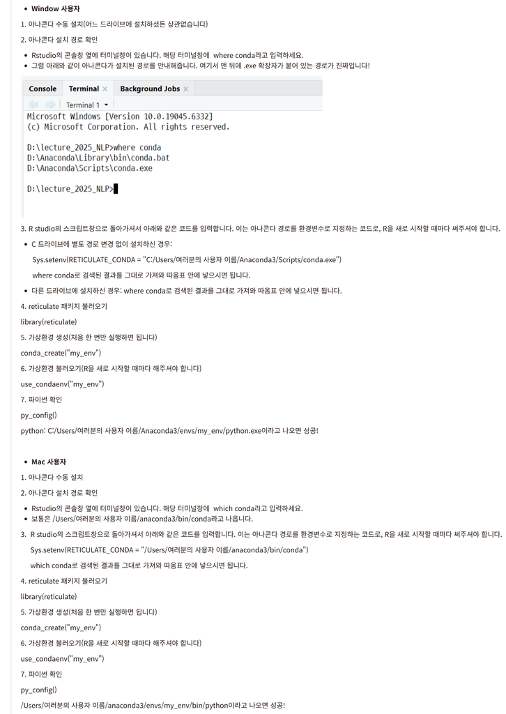

- 3단계: **kiwipiepy** 패키지 설치하기

```r
# pip을 사용하여 kiwipiepy 패키지 설치하기.
py_install("kiwipiepy", pip = TRUE)
```

- 4단계: R에서 **kiwipiepy** 사용하기

```r
# kiwipiepy 모듈 가져오기.
kiwi <- import("kiwipiepy")

# kiwipiepy 형태소 분석기 인스턴스 생성하기.
kiwi_analyzer <- kiwi$Kiwi()

# 분석할 텍스트 준비하기.
text <- "아버지가방에들어가심 ㅋㅋㅋ"

# 텍스트 분석하기.
analysis_result <- kiwi_analyzer$tokenize(text)

# 결과 출력하기.
analysis_result
```

```
## [[1]]
## Token(form='아버지', tag='NNG', start=0, len=3)
##
## [[2]]
## Token(form='가', tag='JKS', start=3, len=1)
##
## [[3]]
## Token(form='방', tag='NNG', start=4, len=1)
##
## [[4]]
## Token(form='에', tag='JKB', start=5, len=1)
##
## [[5]]
## Token(form='들어가', tag='VV', start=6, len=3)
##
## [[6]]
## Token(form='시', tag='EP', start=9, len=1)
##
## [[7]]
## Token(form='ᆷ', tag='EF', start=9, len=1)
##
## [[8]]
## Token(form='ㅋㅋㅋ', tag='SW', start=11, len=3)
```

##### c. 문서 단위로 텍스트 형태소 분석하기

- 문자열이 아닌 문서 단위로 텍스트 형태소 분석하기.
- 분석 대상 말뭉치
  - 네이버 영화 리뷰 데이터셋(Naver sentiment movie corpus, NSMC): 네이버 영화 리뷰 20만 건이 실린 NLP용 데이터셋. 훈련용 셋 15만 건 + 검증용 셋 5만 건으로 구성.
  - **bitNLP** 패키지에 훈련용 셋 `data(movie_ratings_train)`과 검증용 셋 `data(movie_ratings_test)`이 티블 형식으로 포함되어 있음. 직접 웹에서 다운받을 필요 없음.

###### 가. 단계 1: **kiwipiepy**를 사용한 품사분석 함수 정의하기

```r
# 파이썬에서 Kiwi 클래스 불러오기
# kiwipiepy 라이브러리에서 'Kiwi'라는 분석기 클래스를 불러와 초기화하기.
# 이 kiwi 객체가 실제 형태소 분석 작업을 수행하는 도구가 됨.
kiwi <- import("kiwipiepy")$Kiwi()

analyze_pos_kiwi <- function(text) {
  # kiwipiepy의 analyze() 함수로 분석하기.
  results <- kiwi$analyze(text)

  # purrr 패키지의 map_dfr 함수를 사용해 파이썬 객체에서 형태소와 품사 태그 추출.
  # .x는 각 형태소 객체를 의미하며, '$form'과 '$tag'로 내용(문자열 벡터)을 가져옴.
  tagged_tokens <- map_dfr(results[[1]][[1]], ~tibble( # results는 여러 겹의 리스트로 되어 있는데, 이때 results의 첫 번째 리스트의 첫 번째 요소를 tibble() 함수의 입력으로 사용하겠다는 뜻!
    morph = .x$form, # 형태소 추출.
    pos = .x$tag # 품사 추출.
  ))

  # 불용어 목록 정의하기("형태소/품사태그" 형식).
  stop_words_pos <- c("이/VCP", "것/NNB", "곳/NNG", "곳/NNB", "하/VX", "하/VV", "수/NNB", "되/VV",
                      "하/XSA", "들/XSN", "되/XSA", "되/XSV", "하/XSV", "이/VCP", "이/VV", "적/XSN")

  # 정규표현식을 사용해 조사, 어미, 구두점, 불용어를 정확하게 제거하기.
  filtered_tokens <- tagged_tokens %>%
    filter(!str_detect(pos, "^J"), # J로 시작하는 조사 제거([EX] JKS, JKC).
           !str_detect(pos, "^E"), # E로 시작하는 어미 제거([EX] EF, EP).
           !str_detect(pos, "SF|SP|SS") # 구두점 제거. "ㅋ"나 "ㅎ" 같은 자모는 SW로 분류되므로 S로 시작되는 모든 기호를 지워선 안 됨.
           ) %>%
    mutate(tagged_morph = str_c(morph, "/", pos)) %>% # 형태소와 품사 태그를 '/'로 합쳐서 새로운 칼럼 만들기.
    filter(!tagged_morph %in% stop_words_pos) # "형태소/품사태그" 칼럼에 대해 불용어 목록으로 필터링하기.

  return(list(tagged_morphs = filtered_tokens$tagged_morph)) # 필터링된 토큰들의 리스트 만들기. 리스트 내 요소들에 대한 명명은 tagged_morphs로!
}
```

###### 나. 단계 2: 자체 제작 함수를 통해 형태소 단위로 문서 토큰화하기

```r
# 분석할 텍스트.
library(bitNLP)
library(stringi) # 문자열을 UTF-8로 만들기 위한 함수가 포함된 패키지.
data(movie_ratings_train) # NSMC 데이터셋 중 훈련용 셋 15만 리뷰.

set.seed(123) # 난수 고정용.
movie_ratings_train_1000 <- sample_n(movie_ratings_train, size = 1000) %>% # 시간 관계상 1000개의 리뷰만 랜덤 추출.
  mutate(id = as.integer(id)) # id가 숫자임에도 불구하고 문자열 형식으로 되어 있음. 나중에 문제가 될 수 있으므로 미리 정수로 바꿔주기.

# map 함수를 사용하여 각 텍스트에 토큰화 함수 적용하기.
movie_ratings_train_tokenized <- movie_ratings_train_1000 %>%
  filter(document != "") %>%
  drop_na() %>%
  mutate(document = stri_enc_toutf8(document), # 모든 행의 인코딩을 UTF-8로 바꿈.
         document_tagged = map(document, analyze_pos_kiwi), # document에 대해 자체 제작 함수 analyze_pos_kiwi를 적용.
         document_tagged = map_chr(document_tagged, ~str_c(.x$tagged_morphs, collapse = " ")) # 품사 태깅된 형태소를 띄어쓰기 단위로 결합한 문자열 벡터로 만들기.
         ) %>%
  mutate(morp = str_remove_all(document_tagged, "-[A-Z]{1,3}|/[A-Z]{1,3}")) # 품사 태그 제거.
save(movie_ratings_train_tokenized, file = "movie_ratings_train_tokenized.rda")

# 결과 확인하기.
movie_ratings_train_tokenized
```

```
## # A tibble: 1,000 × 5
##          id
##       <int>
##  1  9234563
##  2  9104198
##  3  2399392
##  4  6624535
##  5 10270535
##  6  8411543
##  7  8962204
##  8  9843324
##  9  3252302
## 10  6618330
##    document
##    <chr>
```

[output cut: 47 more lines]

##### d. 배치(batch) 단위로 텍스트 형태소 분석하기(optional: 대규모 말뭉치 분석 작업 시 응용 권장)

- 배치, 즉 문서의 묶음 단위로 텍스트 형태소 분석하기.
- 배치의 크기는 RAM 용량에 의해 좌우됨. RAM 용량이 충분히 크면 배치 크기를 1,000개까지도 할 수 있음.

###### 가. 단계 1: `kiwi` 인스턴스 만들고, 말뭉치를 배치로 나누기

```r
# 필요한 라이브러리 불러오기
library(reticulate)
library(tidyverse)

use_condaenv("my_env") # 새 세션마다 설정.
```

```r
kiwi <- import("kiwipiepy")$Kiwi()

# 불용어 목록 정의 ("형태소/품사태그" 형식)
# 형태소/품사태그([EX] "하/XSA") 형태로 불용어를 정의하여 정확도 높임.
stop_words_pos <- c("이/VCP", "것/NNB", "곳/NNG", "곳/NNB", "하/VX", "하/VV", "수/NNB", "되/VV",
                    "하/XSA", "들/XSN", "되/XSA", "되/XSV", "하/XSV", "이/VCP", "이/VV", "적/XSN") # 영화 리뷰이므로 "영화"라는 명사를 불용어 목록에 포함시킬 수도 있음.

# 대용량 말뭉치
movie_ratings_train_1000
```

```
## # A tibble: 1,000 × 3
##          id
##       <int>
##  1  9234563
##  2  9104198
##  3  2399392
##  4  6624535
##  5 10270535
##  6  8411543
##  7  8962204
##  8  9843324
##  9  3252302
## 10  6618330
##    document
##    <chr>
```

[output cut: 23 more lines]

```r
# 말뭉치를 배치로 나누기
batch_size <- 200 # # 한 번에 처리할 문서의 수를 200개로 설정.
batched_list <- movie_ratings_train_1000 %>%
  group_by(batch_id = ceiling(row_number() / batch_size)) %>% # 배치 ID 기준으로 그루핑하기. ceiling() 함수는 어떤 숫자를 가장 가까운 정수로 올림하는 함수. 1~200, 201~400 단위로 배치 ID 만듦.
  group_split() # 만들어진 배치 ID를 기준으로 데이터를 쪼개어 리스트로 만듦.

# final_data 결과를 저장할 빈 티블의 각 칼럼에 대한 특성 미리 규정해두기.
# movie_ratings_train_1000의 칼럼 구성에 맞춰서 규정해둔 것임. 다른 칼럼 구성을 가진 말뭉치는 그에 맞춰 변형하면 됨.
# 단, 맨뒤의 pos_analyzed 칼럼은 자체 제작 함수를 통해 생성될 칼럼의 제목이므로 그대로 놔두어야 함.
final_data <- tibble(id=integer(), document=character(), label=integer(), pos_analyzed=character()) # integer는 정수, character는 문자열.
```

###### 나. 단계 2: 이중 for 구문으로 품사 태깅된 텍스트 문자열 생성하기

```r
# 바깥쪽 for 루프: 'batched_list'라는 배치 리스트를 하나씩 순회.
# i는 1, 2, 3... 각 배치의 인덱스를 나타냄. 1000개를 200개로 나누었으므로 배치 리스트의 총 길이는 5가 될 것임.
for (i in 1:length(batched_list)) {
  current_batch <- batched_list[[i]] # 현재 순서의 배치 데이터(티블)를 가져옴.

  # kiwipiepy로 현재 배치(문서들)를 한꺼번에 분석.
  # kiwi$analyze()로 파이썬 이터레이터 생성(현재 배치 문서들을 한꺼번에 분석).
  # 이 함수는 결과를 이터레이터(iterater)라는 파이썬 객체로 반환. 다음 요소를 차례대로 하나씩 꺼내서 처리해주는 for 구문과 비슷한 역할을 함.
  results_iter <- kiwi$analyze(current_batch$document)

  # batch_results 결과를 저장할 빈 리스트를 미리 필요한 크기만큼 만들라고 지시하기.
  # 이 줄은 R의 속도를 향상시키는 중요한 최적화 기법.
  # vector() 함수에게 리스트 타입의 객체를 만들라고 지시. length(current_batch$document)는 만들 리스트의 길이 미리 지정.
  # current_batch$document는 배치에 있는 모든 문서를 담고 있는 벡터.
  # 배치가 20개면, batch_results는 20개의 리스트가 됨. 단, 각 배치에 포함된 문서의 개수에 따라 개별 리스트의 길이는 달라질 수 있음.
  batch_results <- vector("list", length(current_batch$document))

  # 안쪽 for 루프: 현재 배치 안에 있는 각 문서를 하나씩 처리.
  # j는 1, 2, 3... 각 문서의 인덱스를 나타냄.
  for (j in 1:length(current_batch$document)) {

    # iter_next()를 통해 이터레이터에서 다음 분석결과를 하나씩 꺼냄. 마치 컨베이어 벨트에서 물건을 하나씩 집어드는 것과 같음.
    results_1 <- iter_next(results_iter)

    # results_1이 아예 존재하지 않거나(is.null = TRUE), 그 안에 아무것도 들어 있지 않을 경우를 대비.
    if (is.null(results_1) || length(results_1) == 0) { # 첫 번째 요소에 대해서만 논리 연산을 수행. 첫 번째 요소가 TRUE이면, 뒤에 있는 나머지 요소는 평가 안 하고 넘어감.
      tagged_tokens <- tibble(morph = character(), pos = character()) #  results_1에 문제가 있을 경우, 빈 티블을 tagged_tokens에 할당하기.
    } else {

      toks <- results_1[[1]][[1]] # 분석결과의 첫 번째 품사 후보(가장 가능성 높은 결과) 가져오기.

      # purrr 패키지의 map_chr 함수를 사용해 파이썬 객체에서 형태소와 품사 태그를 추출.
      # .x는 각 형태소 객체를 의미하며, '$form'과 '$tag'로 내용(문자열 벡터)을 가져옴.
      tagged_tokens <- tibble(
        morph = map_chr(toks, ~ .x$form), # morph(형태소) 칼럼과 pos(품사 태그) 칼럼으로 이루어진 티블 생성.
        pos   = map_chr(toks, ~ .x$tag)
      )
    }

  # 정규표현식을 사용해 하나의 문자열을 대상으로 조사, 어미, 구두점, 불용어를 정확하게 제거.
  filtered_tokens <- tagged_tokens %>%
    filter(!str_detect(pos, "^J"), # J로 시작하는 조사 제거([EX] JKS, JKC).
           !str_detect(pos, "^E"), # E로 시작하는 어미 제거([EX] EF, EP).
           !str_detect(pos, "SF|SP|SS") # 구두점 제거. "ㅋ"나 "ㅎ" 같은 자모는 SW로 분류될 가능성이 높ㅇ므로 S로 시작되는 모든 기호/문자열을 지워선 안 됨.
           ) %>%
    # 형태소와 품사 태그를 '/'를 사이에 두고 합쳐서 새로운 칼럼 tagged_morph 만들기.
    mutate(tagged_morph = str_c(morph, "/", pos)) %>%
    # "형태소/품사태그" 칼럼에 대해 불용어 리스트로 필터링하기.
    filter(!tagged_morph %in% stop_words_pos)

  # 필터링을 하자 남은 토큰이 하나도 없다면 다음의 메시지 출력하기.
  if (nrow(filtered_tokens) == 0) { # filtered_tokens 티블은 각 행이 개별 형태소로 이루어져 있음. 모든 형태소가 제거됐다면 행의 수는 0이 될 것.
    message("이 배치의 ", j, "번째 문서의 모든 토큰이 필터로 걸러졌음.")
  }

  # 필터링을 마치면 "형태소/품사" 형식으로 품사 태깅이 된 토큰 만들기.
  batch_results[[j]] <- str_c(filtered_tokens$morph, filtered_tokens$pos, sep = "/")
  } # 안쪽 for 루프 끝!

  # 현재 배치의 분석 결과를 원래 데이터와 결합하기.
  batch_tibble <- tibble(
    id = current_batch$id, # NSMC 데이터셋의 id 칼럼.
    document = current_batch$document, # NSMC 데이터셋의 document 칼럼.
    label = current_batch$label, # NSMC 데이터셋의 label 칼럼.
    pos_analyzed = map_chr(batch_results, ~str_c(.x, collapse = " ")) # 분석결과에 대하여 품사 태깅된 형태소를 공백 단위로 연결한 문자열 벡터로 만들기.
    )

  # 최종 결과 티블에 현재 배치 단위 분석결과를 합침.
  final_data <- bind_rows(final_data, batch_tibble) %>%
    # 품사 태그를 제거한 순수 형태소만 남긴 문자열 칼럼 morp 생성하기.
    mutate(morp = str_remove_all(pos_analyzed, "-[A-Z]{1,3}|/[A-Z]{1,3}"))
  } # 바깥쪽 for 루프 끝!

final_data
```

```
## # A tibble: 1,000 × 5
##          id
##       <int>
##  1  9234563
##  2  9104198
##  3  2399392
##  4  6624535
##  5 10270535
##  6  8411543
##  7  8962204
##  8  9843324
##  9  3252302
## 10  6618330
##    document
##    <chr>
```

[output cut: 47 more lines]

## (4) 불용어(stop words) 목록

### 1) 불용어 목록

- 불용어
  - 정의: 분석에 사용되지 않는 단어.
  - 중요
    - 텍스트의 성격과 분석 목적에 따라 불용어를 어떻게 정의하고 처리하느냐는 모델의 성능과 해석력에 큰 영향을 미칠 수 있음.
    - 분석에 필요한 텍스트의 규모를 최대한 축소함으로써 처리용량 이슈에 효과적으로 대처할 수 있음.
  - 종류
    - 빈도가 높아 분석에 유용하지 않은 단어. 영어의 전치사가 대표적인 예. 비내용어([EX] 조사, 어미, 숫자, 특수문자, 구두점, 공백문자, 기호)도 포함 가능.
    - 텍스트의 유형에 따라 달라질 수 있음. 의료 텍스트라면, “환자”, “병원”, “의사”라는 단어는 빈도는 높지만 정보 값은 그리 높지 않을 수 있음.
  - 불용어의 선정 방법
    - 범용: 일반적으로 대부분의 텍스트 분석에 널리 적용 가능 불용어 목록을 사용하는 경우.
    - 사용자 정의: 분석의 목적에 따라 사용자가 직접 정의하는 경우. 감탄사/접속부사([EX] 와, 흠, 글쎄, 그런데, 하지만)는 범용 불용어 목록에 흔히 포함되곤 하지만, 필요([EX] 영화나 상품 리뷰)에 따라 분석의 대상이 될 수도 있음.

#### 1) 영어

- **tidytext** 내장 불용어 목록: `data(stop_words)`를 불러와 사용 가능.

```r
# 영어 불용어 목록 불러오기.
data(stop_words)
stop_words
```

```
## # A tibble: 1,149 × 2
##    word        lexicon
##    <chr>       <chr>
##  1 a           SMART
##  2 a's         SMART
##  3 able        SMART
##  4 about       SMART
##  5 above       SMART
##  6 according   SMART
##  7 accordingly SMART
##  8 across      SMART
##  9 actually    SMART
## 10 after       SMART
## # ℹ 1,139 more rows
```

#### 2) 한국어

- 길호현(2018)의 한국어 불용어 목록: 자세한 불용어 목록 추출 절차는 해당 논문 참조.

**[그림 3] 길호현(2018)의 한국어 불용어 목록**

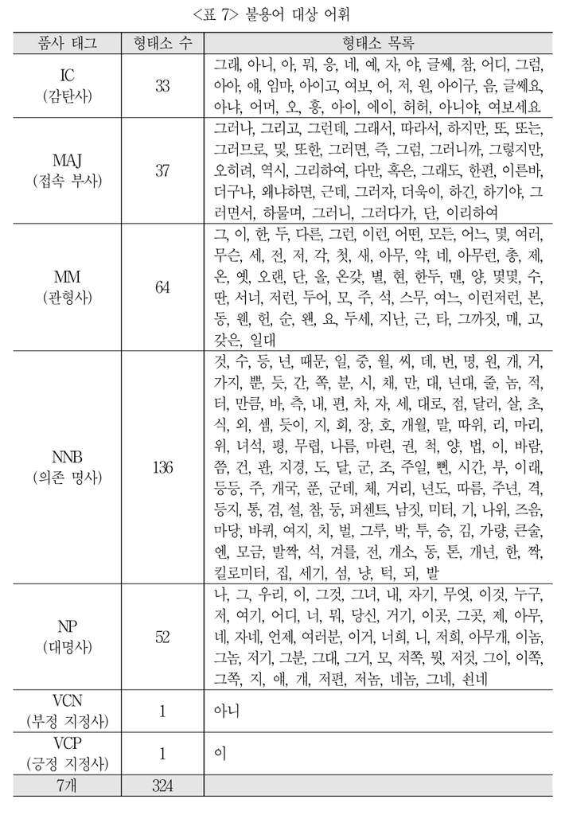

- 노성화 & 김정(2022)의 한국어 범용 불용어 목록: 자세한 불용어 목록 추출 절차는 해당 논문 참조.

**[그림 4] 노성화 & 김정(2022)의 한국어 불용어 목록**

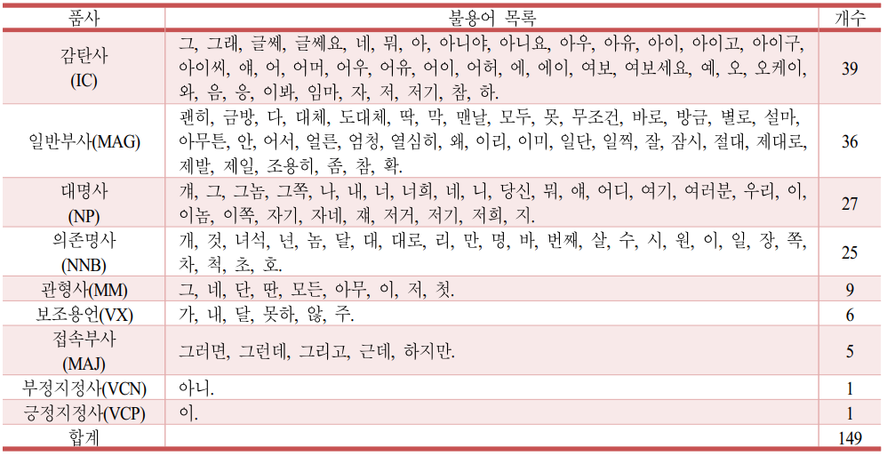

- 불용어 목록 통합본: 상술한 두 불용어 목록 통합본 엑셀 파일을 강의 담당자가 수업자료 레포지토리에 올려두었음.

```r
# 불용어 목록 저장 경로 생성하기.
dir.create("texts/stop_words" recursive = TRUE) # 반드시 프로젝트 파일을 열어두고 그곳에서 R 스크립트를 실행해야 함! 만약 상위 폴더인 texts 폴더가 없다면 recursive = TRUE로 설정해야 함.
stop_words.path <- "texts/stop_words/korean_stop_word_list.xlsx"
stop_words_url <- "https://github.com/cognitivepsychology/NLP_2025/raw/main/%EA%B8%B8%ED%98%B8%EC%97%B0_%EB%85%B8%EC%84%B1%ED%99%94%26%EA%B9%80%EC%A0%95%20%ED%86%B5%ED%95%A9%20%EB%B6%88%EC%9A%A9%EC%96%B4%20%EB%AA%A9%EB%A1%9D.xlsx"

# 불용어 목록 다운로드하기.
download.file(url = stop_words_url, # 다운로드받을 파일이 있는 URL.
              destfile = stop_words.path, # 파일을 다운로드받을 경로.
              mode = "wb" # 바이너리 형식으로 저장.
)

# 티블 형식으로 불용어 목록 불러오기.
library(readxl) # 엑셀 파일을 R로 불러오는 패키지.
gil_noh_stopwords_final <- read_excel(stop_words.path)
save(gil_noh_stopwords_final, file="gil_noh_stopwords_final.rda")
```

### 2) 불용어 목록 제외한 단어 빈도 계산하기

- 실습대상 말뭉치: 모두의 말뭉치 비출판물(NIKL_NP_v1.1). 주로 일반인의 일기나 수필 또는 소설 습작으로 구성됨.

```r
# 지난 시간에 만들어둔 300개 XML 텍스트 티블 불러오기.
load("sjml_result.rda")

# 범용 한국어 불용어 목록 티블 불러오기.
load("gil_noh_stopwords_final.rda")
```

- 불용어 목록 제외 전 vs. 후 단어 빈도 비교하기.

```r
# 불용어 목록 제외 전 단어 빈도 분석하기.
sjml_result %>%
  mutate(text = enc2utf8(text)) %>%
  unnest_tokens(morp, text, token = RcppMeCab::pos, to_lower = F) %>%
  filter(!str_detect(morp, "J[A-Z]{1,3}|E[A-Z]{1,3}|S[A-Z]{1,3}")) %>%
  count(morp, sort = TRUE) # morp(품사 태깅된 형태소)의 빈도 분석(SORT = TRUE: 내림차순으로 배열).
```

```
## # A tibble: 4,923 × 2
##    morp         n
##    <chr>    <int>
##  1 이/VCP     601
##  2 것/NNB     509
##  3 하/VV      500
##  4 나/NP      343
##  5 않/VX      304
##  6 있/VV      293
##  7 생각/NNG   279
##  8 수/NNB     278
##  9 되/VV      254
## 10 없/VA      238
## # ℹ 4,913 more rows
```

```r
# 불용어 목록 제외 후 단어 빈도 분석하기
sjml_result %>%
  mutate(text = enc2utf8(text)) %>%
  unnest_tokens(morp, text, token = RcppMeCab::pos, to_lower = F) %>%
  filter(!str_detect(morp, "J[A-Z]{1,3}|E[A-Z]{1,3}|S[A-Z]{1,3}")) %>%
  anti_join(gil_noh_stopwords_final[, 5], by = c("morp" = "stop_words_tagged")) %>% # anti_join 함수를 통해 불용어 목록에 포함된 형태소(품사 태깅된 형태소)만 제거하기.
  count(morp, sort = TRUE)
```

```
## # A tibble: 4,707 × 2
##    morp         n
##    <chr>    <int>
##  1 하/VV      500
##  2 있/VV      293
##  3 생각/NNG   279
##  4 되/VV      254
##  5 없/VA      238
##  6 있/VX      233
##  7 사람/NNG   204
##  8 일/NNG     184
##  9 같/VA      182
## 10 아이/NNG   161
## # ℹ 4,697 more rows
```

- 불용어 제거 방법
  - `anti_join` 함수 사용: 불용어 목록과 목표 텍스트를 `morp`(토큰) 기준으로 병합하되, 불용어에 있는 단어는 제거하도록 명령.
  - `filter` 함수 사용: `str_detect` 함수 및 부정연산자 `!`와 결합하여 추가로 불용어를 걸러낼 수 있음.

```r
# 빈도는 높지만 정보 값은 적은 형태소를 새로운 불용어 목록에 추가하기.
stop_words_added <- c("이/VCP", "것/NNB", "곳/NNG", "곳/NNB", "하/VX", "하/VV", "수/NNB", "되/VV",
                      "하/XSA", "들/XSN", "되/XSA", "되/XSV", "하/XSV", "이/VCP", "이/VV", "적/XSN")

# anti_join과 filter 함수를 함께 사용하여 새로운 불용어 추가로 제거하기.
sjml_result %>%
  mutate(text = enc2utf8(text)) %>%
  unnest_tokens(morp, text, token = RcppMeCab::pos, to_lower = F) %>%
  filter(!str_detect(morp, "J[A-Z]{1,3}|E[A-Z]{1,3}|S[A-Z]{1,3}")) %>%
  anti_join(gil_noh_stopwords_final[, 5], by = c("morp" = "stop_words_tagged")) %>%
  filter(!morp %in% stop_words_added) %>% # morp 칼럼에 있는 새로운 불용어 찾아낸 뒤 filter 함수에 !를 더하여 제거하기.
  count(morp, sort = TRUE)
```

```
## # A tibble: 4,701 × 2
##    morp         n
##    <chr>    <int>
##  1 있/VV      293
##  2 생각/NNG   279
##  3 없/VA      238
##  4 있/VX      233
##  5 사람/NNG   204
##  6 일/NNG     184
##  7 같/VA      182
##  8 아이/NNG   161
##  9 좋/VA      150
## 10 시간/NNG   135
## # ℹ 4,691 more rows
```

# 2. 감성분석(sentiment analysis) 수행하기

## (1) 감성분석 개관

- 정의: 텍스트에 담긴 사람의 감정이나 의견을 파악하는 기술. 컴퓨터를 통해 문장이나 글이 긍정적인지, 부정적인지, 혹은 중립적인지를 자동으로 분석.
- 예시
  - 영화 리뷰 분석
    - 입력 텍스트: “이 영화는 정말 재미있었지만, 배우들의 연기는 아쉬웠다.”
    - 분석결과: 이 문장을 분석하면, **재미있었지만**이라는 단어 때문에 긍정적인 감성으로 분류 가능. 하지만 더 자세히 분석하면 **연기는 아쉬웠다**는 부분에서 부정적인 감성도 함께 포함.
  - 상품 후기 분석
    - 입력 텍스트: “이 스피커는 음질이 뛰어나지만, 디자인이 별로다.”
    - 분석 결과: 감성분석 모델은 **뛰어나다**라는 긍정적인 단어와 **별로**라는 부정적인 단어를 찾아내고, 이 둘의 비중을 계산하여 전체적인 감성을 판단. 예를 들어, **음질이 뛰어나다**는 긍정적인 감성을, **디자인이 별로**는 부정적인 감성을 가지는 식으로 분석.
- 목적: 단순히 텍스트가 긍정적이냐 부정적이냐를 나누는 것을 넘어, 왜 그런 감정을 느끼는지까지 이해하는 데 도움을 줄 수 있음.

## (2) 한국어 감정사전

### 1) 군산대학교(KNU) 감정사전

#### A. 소개

- 제작자: 군산대학교 소프트웨어융합공학과 Data Intelligence Lab에서 개발한 한국어 감정 사전.
- 웹사이트: [링크](https://github.com/park1200656/KnuSentiLex).
- 사전 구축에 사용된 자료 출처
  - 국립국어원 표준국어대사전의 뜻풀이 분석을 통한 긍부정 추출.
  - 김은영(2004)의 긍부정어 목록.
  - SentiWordNet 및 SenticNet-5.0에서 주로 사용되는 긍부정어 번역.
  - 사전 구축 당시 온라인에서 많이 사용되던 축약어 및 긍부정 이모티콘 목록.
- 특징
  - 표준국어대사전을 구성하는 각 단어의 뜻풀이를 분석하여 긍부정어를 추출.
  - 1-그램, 2-그램, n-그램(어구, 문형), 축약어, 이모티콘 등의 다양한 종류의 긍부정어 포함.
  - 영화, 음악, 자동차 등 어떤 영역(domain)에도 사용될 수 있는 보편적인 긍부정어로 구성.
- 구성
  - 매우 긍정(2점): 2,597개.
  - 긍정(1점): 2,266개.
  - 중립(0점): 154개.
  - 부정(-1점): 5,029개.
  - 매우 부정(-2점): 4,797개.
- 파일 링크
  - JSON 파일: SentiWord_info.json
  - txt 파일: SentiWord_Dict.txt

#### B. **bitNLP** 패키지로 감성분석 하기

- 사전의 구성
  - `polarity`: 4개의 변수와 14,841개의 관측치로 구성된 티블.
  - 티블의 칼럼
    - `word` 칼럼: 사전에 수록된 단어들.
    - `word_root` 칼럼: 단어의 어근.
    - `polarity`: 극성, 즉 긍부정에 대한 정보. 매우 부정(-2), 부정(-1), 중립(0), 긍정(1), 매우 긍정(2)으로 구성.
    - `n_gram`: n-그램의 크기.

```r
library(bitNLP)
data(sentiment_dic) # KNU 감성사전 불러오기.
View(sentiment_dic) # RStudio에서 긍부정어 목록 살펴보기.
```

- **bitNLP** 패키지로 감성분석 하기
  - `get_polarity`: KNU 감정사전을 활용하여 문서의 감성분석 결과를 반환해주는 함수.
  - `get_polarity`의 논항
    - `doc`: KNU 감정사전을 활용하여 감성분석을 수행할 문자열 벡터.
    - `n`: n-그램(gram) 토큰화 계수. [EX] 1이면 한 단어, 2이면 연접한 두 단어가 한 토큰이 됨.
    - `indiv`: 여러 개의 문서일 때 개별 문서 단위로 결과를 반환할지 선택.
      - `TRUE`: 티블에서 개별 문서 단위로 각각의 관측치 반환. 기본값은 `TRUE`.
      - `FALSE`: 티블에서 여러 개의 문서를 뭉뚱그려 하나의 관측치로 반환.
  - 분석결과 티블에 포함된 칼럼
    - `n_match`: 감성사전에 매치된 토큰 개수.
    - `n_negative`: 감성사전의 부정단어와 매치된 토큰 개수.
    - `n_positive`: 감성사전의 긍정단어와 매치된 토큰 개수.
    - `n_neutral`: 감성사전의 중립단어와 매치된 토큰 개수.
    - `negative`: 감성사전의 부정단어와 매치된 토큰 점수의 합.
    - `positive`: 감성사전의 긍정 단어와 매치된 토큰 점수의 합.
    - `polarity`: 감성의 극성. (positive - negative) / (positive + negative). 양수면 긍정적 & 음수면 부정적.
  - 감성사전 채점(lexicon scoring) 방식 채택
    - 감성사전(lexicon): 감정단어 목록. [EX] “좋다” → +2점, “싫다”” → -2점, “최고” → +3점 등.
    - 채점(scoring): 텍스트에 등장하는 단어들을 감성사전과 비교해서 각 단어의 감성점수를 합산하거나 평균내는 방식.
- NSMC 데이터셋을 대상으로 감성분석 하기

```r
# 오류 발생 시 NA를 반환하도록 get_polarity 함수 purrr의 possibly 함수로 감싸기.
possibly_get_polarity <- purrr::possibly(get_polarity, otherwise = NA)

# map을 사용해 각 문서에 대해 개별적으로 함수 적용: 리뷰 원문에 적용.
movie_ratings_result.KNU <- movie_ratings_train_tokenized %>%
  mutate(sentiment = map(document, possibly_get_polarity)) %>%
  unnest(sentiment)
movie_ratings_result.KNU
```

```
## # A tibble: 1,000 × 12
##          id
##       <int>
##  1  9234563
##  2  9104198
##  3  2399392
##  4  6624535
##  5 10270535
##  6  8411543
##  7  8962204
##  8  9843324
##  9  3252302
## 10  6618330
##    document
##    <chr>
```

[output cut: 59 more lines]

```r
# map을 사용해 각 문서에 대해 개별적으로 함수 적용: 분석된 토큰에 적용(토큰화 여부가 큰 영향 X).
movie_ratings_result.KNU.1 <- movie_ratings_train_tokenized %>%
  mutate(sentiment = map(morp, possibly_get_polarity)) %>%
  unnest(sentiment)
movie_ratings_result.KNU.1
```

```
## # A tibble: 1,000 × 12
##          id
##       <int>
##  1  9234563
##  2  9104198
##  3  2399392
##  4  6624535
##  5 10270535
##  6  8411543
##  7  8962204
##  8  9843324
##  9  3252302
## 10  6618330
##    document
##    <chr>
```

[output cut: 59 more lines]

- 모두의 말뭉치 비출판물(NIKL_NP_v1.1) 데이터셋을 대상으로 감성분석 하기

```r
# 오류 발생 시 NA를 반환하도록 get_polarity 함수 possibly 함수로 감싸기.
possibly_get_polarity <- purrr::possibly(get_polarity, otherwise = NA)

# map을 사용해 각 문서에 대해 개별적으로 함수 적용: 리뷰 원문에 적용.
sjml_result.KNU <- sjml_result.filtered %>%
  mutate(sentiment = map(text, possibly_get_polarity)) %>%
  unnest(sentiment)
sjml_result.KNU
```

```
## # A tibble: 10 × 16
##    title                     category               author_age author_occupation
##    <chr>                     <chr>                       <dbl> <chr>
##  1 아내의 생일상             비출판물 > 수필                45 직장인/전문직
##  2 소금이 온다               비출판물 > 감상문               7 초등학생
##  3 졸업                      비출판물 > 일기                24 대학생/대학원생
##  4 감사일기                  비출판물 > 감상문              47 직장인/전문직
##  5 환경과 패스트패션         비출판물 > 기타 > 칼럼         44 직장인/전문직
##  6 58년 개띠                 비출판물 > 일기                61 전업주부
##  7 바이러스                  비출판물 > 수필                28 직장인/전문직
##  8 일하기싫다                비출판물 > 일기                27 직장인/전문직
##  9 힘들다는 것이 어떤 것인가 비출판물 > 수필                44 직장인/전문직
## 10 내  인생 영화, 세 얼간이  비출판물 > 감상문              45 직장인/전문직
##    author_sex author_submission author_handwriting
##    <chr>      <chr>             <chr>
```

[output cut: 46 more lines]

```r
# map을 사용해 각 문서에 대해 개별적으로 함수 적용: 분석된 토큰에 적용.
sjml_result.KNU.1 <- sjml_result.filtered %>%
  mutate(sentiment = map(text_1, possibly_get_polarity)) %>%
  unnest(sentiment)
sjml_result.KNU.1
```

```
## # A tibble: 10 × 16
##    title                     category               author_age author_occupation
##    <chr>                     <chr>                       <dbl> <chr>
##  1 아내의 생일상             비출판물 > 수필                45 직장인/전문직
##  2 소금이 온다               비출판물 > 감상문               7 초등학생
##  3 졸업                      비출판물 > 일기                24 대학생/대학원생
##  4 감사일기                  비출판물 > 감상문              47 직장인/전문직
##  5 환경과 패스트패션         비출판물 > 기타 > 칼럼         44 직장인/전문직
##  6 58년 개띠                 비출판물 > 일기                61 전업주부
##  7 바이러스                  비출판물 > 수필                28 직장인/전문직
##  8 일하기싫다                비출판물 > 일기                27 직장인/전문직
##  9 힘들다는 것이 어떤 것인가 비출판물 > 수필                44 직장인/전문직
## 10 내  인생 영화, 세 얼간이  비출판물 > 감상문              45 직장인/전문직
##    author_sex author_submission author_handwriting
##    <chr>      <chr>             <chr>
```

[output cut: 46 more lines]

### 2) KOSAC(Korean Sentiment Analysis Corpus: 한국어 감정 및 의견 분석 코퍼스) 감정사전

#### B. **bitNLP** 패키지로 감성분석 하기

- 사전의 구성
  - `polarity`: 10개의 변수와 15,736개의 관측치로 구성된 티블.
  - 티블의 칼럼
    - `ngram`: n-그램의 크기.
    - `freq`: 빈도.
    - `COMP`: complex일 확률.
    - `NEG`: negative일 확률.
    - `NEUT`: neutral일 확률.
    - `None`: none일 확률.
    - `POS`: positive일 확률.
    - `max.value`: 해당 단어가 가질 수 있는 최대 감성점수. 특정 감정의 강도. 긍정점수는 1, 부정점수는 -1이 최댓값.
    - `max.prop`: 감정의 극성 확률. 해당 단어가 긍정 또는 부정 감성을 가질 확률. 0-1 사이에 존재. 1에 가까울수록 해당 감성으로 분류될 확률 높음.
    - `type`: “kosac”으로 되어 있음.

```r
library(bitNLP)
data(polarity) # KOSAC 감성사전 불러오기.
View(polarity) # RStudio에서 긍부정어 목록 살펴보기.
```

- **bitNLP** 패키지로 감성분석 하기
  - `get_opinion`: KOSAC 감정사전을 활용하여 문서의 감성분석 결과를 반환해주는 함수.
  - `get_opinion`의 논항
    - `doc`: KOSAC 감정사전을 활용하여 감성분석을 수행할 문자열 벡터.
    - `n`: n-그램(gram) 토큰화 계수. [EX] 1이면 한 단어, 2이면 연접한 두 단어가 한 토큰이 됨.
    - `agg`: 여러 개의 문서일 때 개별 문서 단위로 결과를 반환할지 선택.
      - `TRUE`: 집계 결과만 반환. 기본값은 `TRUE`.
      - `FALSE`: 분석에 사용된 문자열도 함께 반환.
  - 분석결과 티블에 포함된 칼럼
    - `complex`: 복합적 감정.
    - `negative`: 부정적 감정.
    - `positive`: 긍정적 감정.
    - `neutral`: 중립적 감정.
    - `none`: 해당 없음.
    - `vote`: 감성투표 결과. `POS` 또는 `NEG`.
    - `polarity`: 감정의 극성.
    - `subjectivity`: 문자열이 주관적인지, 객관적인지 나타내는 점수. 범위는 0-1 사이. 점수가 높을수록 작성자의 주관적 의견, 감정, 생각을 담고 있을 확률이 높음.
    - doc: 분석 대상 문자열.
- NSMC 데이터셋을 대상으로 감성분석 하기

```r
# get_opinion 함수를 오류 발생 시 NA를 반환하도록 감싸기.
possibly_get_opinion <- purrr::possibly(get_opinion, otherwise = NA)

# map을 사용해 각 문서에 대해 개별적으로 함수 적용: 리뷰 원문에 적용.
movie_ratings_result.KOSAC <- movie_ratings_train_tokenized %>%
  mutate(sentiment = map(document, ~ possibly_get_opinion(.x, agg = T))) %>%
  unnest(sentiment)
movie_ratings_result.KOSAC
```

```
## # A tibble: 961 × 13
##          id
##       <int>
##  1  9234563
##  2  9104198
##  3  2399392
##  4  6624535
##  5 10270535
##  6  8411543
##  7  9843324
##  8  3252302
##  9  6618330
## 10   701304
##    document
##    <chr>
```

[output cut: 59 more lines]

```r
# map을 사용해 각 문서에 대해 개별적으로 함수 적용: 분석된 토큰에 적용(토큰화한 쪽의 정확도가 좀더 높아 보임).
movie_ratings_result.KOSAC.1 <- movie_ratings_train_tokenized %>%
  mutate(sentiment = map(morp, ~ possibly_get_opinion(.x, agg = T))) %>%
  unnest(sentiment)
movie_ratings_result.KOSAC.1
```

```
## # A tibble: 931 × 13
##          id
##       <int>
##  1  9234563
##  2  9104198
##  3  2399392
##  4  6624535
##  5 10270535
##  6  8411543
##  7  9843324
##  8  3252302
##  9  6618330
## 10   701304
##    document
##    <chr>
```

[output cut: 59 more lines]

- 모두의 말뭉치 비출판물(NIKL_NP_v1.1) 데이터셋을 대상으로 감성분석 하기

```r
# get_polarity 함수를 오류 발생 시 NA를 반환하도록 감싸기.
possibly_get_opinion <- purrr::possibly(get_opinion, otherwise = NA)

# map을 사용해 각 문서에 대해 개별적으로 함수 적용: 리뷰 원문에 적용.
sjml_result.KOSAC <- sjml_result.filtered %>%
  mutate(sentiment = map(text, possibly_get_opinion)) %>%
  unnest(sentiment)
sjml_result.KOSAC
```

```
## # A tibble: 10 × 17
##    title                     category               author_age author_occupation
##    <chr>                     <chr>                       <dbl> <chr>
##  1 아내의 생일상             비출판물 > 수필                45 직장인/전문직
##  2 소금이 온다               비출판물 > 감상문               7 초등학생
##  3 졸업                      비출판물 > 일기                24 대학생/대학원생
##  4 감사일기                  비출판물 > 감상문              47 직장인/전문직
##  5 환경과 패스트패션         비출판물 > 기타 > 칼럼         44 직장인/전문직
##  6 58년 개띠                 비출판물 > 일기                61 전업주부
##  7 바이러스                  비출판물 > 수필                28 직장인/전문직
##  8 일하기싫다                비출판물 > 일기                27 직장인/전문직
##  9 힘들다는 것이 어떤 것인가 비출판물 > 수필                44 직장인/전문직
## 10 내  인생 영화, 세 얼간이  비출판물 > 감상문              45 직장인/전문직
##    author_sex author_submission author_handwriting
##    <chr>      <chr>             <chr>
```

[output cut: 46 more lines]

```r
# map을 사용해 각 문서에 대해 개별적으로 함수 적용: 분석된 토큰에 적용.
sjml_result.KOSAC.1 <- sjml_result.filtered %>%
  mutate(sentiment = map(text_1, possibly_get_opinion)) %>%
  unnest(sentiment)
sjml_result.KOSAC.1
```

```
## # A tibble: 10 × 17
##    title                     category               author_age author_occupation
##    <chr>                     <chr>                       <dbl> <chr>
##  1 아내의 생일상             비출판물 > 수필                45 직장인/전문직
##  2 소금이 온다               비출판물 > 감상문               7 초등학생
##  3 졸업                      비출판물 > 일기                24 대학생/대학원생
##  4 감사일기                  비출판물 > 감상문              47 직장인/전문직
##  5 환경과 패스트패션         비출판물 > 기타 > 칼럼         44 직장인/전문직
##  6 58년 개띠                 비출판물 > 일기                61 전업주부
##  7 바이러스                  비출판물 > 수필                28 직장인/전문직
##  8 일하기싫다                비출판물 > 일기                27 직장인/전문직
##  9 힘들다는 것이 어떤 것인가 비출판물 > 수필                44 직장인/전문직
## 10 내  인생 영화, 세 얼간이  비출판물 > 감상문              45 직장인/전문직
##    author_sex author_submission author_handwriting
##    <chr>      <chr>             <chr>
```

[output cut: 46 more lines]

## (3) 단어별 감성점수 산출하기

### 1) 점 상호정보량(pointwise mutual information, PMI)

- 범용 감성사전의 한계: KNU 감성사전의 사례에서 보듯, 사전에 없는 단어들로 이루어진 텍스트는 정확한 감성분류를 하기 어려움.
- 특정 영역의 말뭉치([EX] 영화 리뷰, 상품 리뷰 등)는 해당 영역에서 자주 사용되는 단어들이 존재. 그 단어들의 감성점수(sentiment score)를 안다면, 범용 사전의 한계를 극복하는 데 도움이 될 수 있을 것.
- **PMI**
  - 정의: 두 단어가 함께 나타날 확률이 따로따로 나타날 확률보다 얼마나 더 높은지를 측정하는 척도. 단어 간 연관성 파악에 도움.
  - 응용
    - 감정의 극성(NSMC에서는 긍정 = 1, 부정 = 0)과 공기하는 단어들을 찾아냄: 긍정으로 분류된 리뷰에 자주 등장하는 단어들은 긍정 감성을, 부정으로 분류된 리뷰에 자주 등장하는 단어들은 부정 감성을 내포할 가능성이 높음.
    - 단어별 감성점수 산출: 긍정 극성과의 PMI 점수가 높은 단어는 높은 긍정점수를, 부정 극성과의 PMI 점수가 높은 단어는 높은 부정점수를 부여. 이렇게 구축된 사전은 유사한 영역의 새로운 텍스트에 대한 감성점수 산출에 사용 가능.
    - 감성점수 산출식: 감성점수 = PMI(긍정 극성과 공기하는 단어 ) - PMI(부정 극성과 공기하는 단어)
    - 리뷰의 총 감성점수 산출: 총점 = (“지루”의 점수) + (“노잼”의 점수) + (“아깝”의 점수).
    - 최종 감성 예측: 총점이 양수면, 긍정 리뷰, 총점이 음수면 부정 리뷰, 0이면 중립 리뷰로 간주.
  - 단점
    - 지루하지 않다” 같은 장형 부정이나 “재미가 없다”처럼 부정어가 포함된 문자열을 처리할 때 한계가 있음.
    - 빈도가 극히 낮은 단어의 경우 분모가 0에 가까워져 PMI 점수가 비정상적으로 높게 산출되는 **폭주(explosion)** 현상을 일으킬 수 있음. 이를 위해 최소 빈도 이하의 단어를 미리 제거할 필요가 있음.

**[그림 5] PMI 계산식**

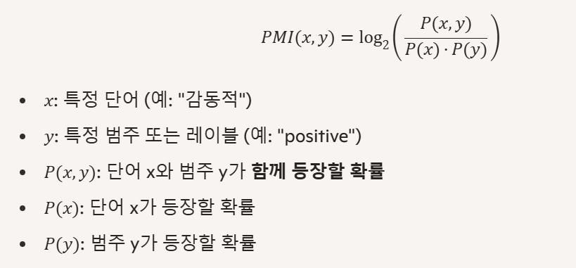

### 2) 단어별 감성점수 산출하기

- 대상 데이터셋: NSMC 훈련용 데이터셋(`data(movie_ratings_train)`). 감성점수 결과물은 주로 영화/드라마 리뷰 감성분류에 사용될 것.

#### A. 단계 1: 데이터프레임 준비 및 토큰화

```r
word_tokens <- movie_ratings_train_tokenized %>%
  unnest_tokens(word, morp) %>%
  filter(!word %in% "영화") %>% # 영화 리뷰이므로 "영화"는 정보 값이 적은 단어임.
  distinct(id, word, label) # 중복되는 행 제외하기.
```

#### B. 단계 2: 각 단어와 감성의 빈도 및 확률 계산하기

```r
min_frequency <- 2 # 최소 빈도 임계값 설정하기.

word_counts <- word_tokens %>%
  count(word, sort = TRUE) %>% # word 칼럼 기준으로 빈도 계산하기.
  filter(n >= min_frequency) %>% # 최소 빈도 2 이상인 단어만 추출하기.
  mutate(p_word = n / sum(n)) #  단어 확률 계산하기.

word_tokens <- word_tokens %>% # word_tokens 재정의하기.
  semi_join(word_counts, by = "word") # semi_join 함수를 통해 word_tokens과 word_counts을 word 칼럼 기준으로 결합함. 그럼 자동적으로 word_tokens은 빈도 2 이상의 토큰만 남게 됨.

sentiment_counts <- word_tokens %>%
  distinct(id, label) %>% # 중복되는 행 제외하기.
  count(label) %>% # label 칼럼을 기준으로 빈도 계산하기.
  mutate(p_sentiment = n / sum(n)) # 극성 확률 계산하기.
```

#### C. 단계 3: 단어-감성 동시 출현 빈도 및 확률 계산하기

```r
word_sentiment_pairs <- word_tokens %>%
  count(word, label, sort = TRUE) %>% # word와 label 칼럼을 기준으로 빈도 계산하기.
  mutate(p_word_sentiment = n / sum(n)) # 특정 단어가 긍/부정 리뷰에 나타날 확률 계산하기.
```

#### D. 단계 4: PMI 계산 및 결과 정리하기

```r
pmi_scores <- word_sentiment_pairs %>%
  left_join(word_counts, by = "word") %>% # word 칼럼을 기준으로 word_counts 티블과 합치기.
  left_join(sentiment_counts, by = "label") %>% # label 칼럼을 기준으로 sentiment_counts 티블과 합치기.
  mutate(pmi = log2(p_word_sentiment / (p_word * p_sentiment))) %>% # PMI 계산하기.
  select(word, label, pmi) %>% # 주요 칼럼 취사선택하기.
  arrange(desc(pmi)) # PMI 기준으로 내림차순 정렬하기.
```

#### E. 단계 5: 감성점수 계산하기

```r
sentiment_score <- pmi_scores %>%
  select(word, label, pmi) %>% # 주요 칼럼 취사선택하기.
  pivot_wider(names_from = label, values_from = pmi, values_fill = 0) %>% # label 칼럼을 그 값(0, 1)에 따라 옆으로 펼치고자 함. 이때 "0"이라는 제목의 칼럼과 "1"이라는 제목의 칼럼이 생성되고, 행으로는 pmi 값이 들어감. 결측값은 0으로 채움.
  mutate(score = `1` - `0`) %>% # 긍정 극성과 특정 단어 간의 PMI - 부정 극성과 특정 단어 간의 PMI
  arrange(desc(score)) %>% # 감성점수 기준으로 내림차순 정렬하기.
  rename(negative = `0`, positive = `1`) %>% # 칼럼 이름 바꿔주기.
  mutate(senti_label = case_when(score > 0 ~  "긍정", # 감성점수가 0 이상이면 "긍정"으로 라벨링.
                                 T ~ "부정")) # 감성점수가 0 이하이면 "부정"으로 라벨링.
save(sentiment_score, file="sentiment_score.rda")
sentiment_score
```

```
## # A tibble: 1,041 × 5
##    word   negative positive score senti_label
##    <chr>     <dbl>    <dbl> <dbl> <chr>
##  1 최고      -2.80    0.887  3.69 긍정
##  2 아쉽      -2.58    0.869  3.45 긍정
##  3 아름답    -2.45    0.857  3.31 긍정
##  4 3         -2.32    0.842  3.16 긍정
##  5 그리고    -2.32    0.842  3.16 긍정
##  6 여운      -2.32    0.842  3.16 긍정
##  7 추천      -2.32    0.842  3.16 긍정
##  8 가슴      -2.16    0.824  2.99 긍정
##  9 재미있    -2.05    0.810  2.86 긍정
## 10 사랑      -1.95    0.795  2.74 긍정
## # ℹ 1,031 more rows
```

#### F. 단계 6: 감성점수 상위/하위 단어 추출하기

```r
top_words <- sentiment_score %>%
  filter(score != 0) %>%
  slice_max(abs(score), n = 20) %>% # 감성점수 절대값 상위 20개만 잘라내기.
  mutate(direction = case_when(score > 0 ~  "positive", # 극성의 방향 정의하기: 감성점수 0 이상이면 "positive"로 라벨링.
                               T ~ "negative")) # # 극성의 방향 정의하기: 감성점수 0 이하면 "negative"로 라벨링.
top_words
```

```
## # A tibble: 23 × 6
##    word   negative positive score senti_label direction
##    <chr>     <dbl>    <dbl> <dbl> <chr>       <chr>
##  1 쓰레기    0.953   -3.81  -4.77 부정        negative
##  2 재미없    0.936   -3.40  -4.33 부정        negative
##  3 별로      0.913   -3.01  -3.92 부정        negative
##  4 최고     -2.80     0.887  3.69 긍정        positive
##  5 개        0.880   -2.59  -3.47 부정        negative
##  6 아쉽     -2.58     0.869  3.45 긍정        positive
##  7 아름답   -2.45     0.857  3.31 긍정        positive
##  8 3        -2.32     0.842  3.16 긍정        positive
##  9 그리고   -2.32     0.842  3.16 긍정        positive
## 10 여운     -2.32     0.842  3.16 긍정        positive
## # ℹ 13 more rows
```

### 3) 감성점수 상위/하위 단어 시각화하기

```r
windowsFonts(NanumGothic = windowsFont("나눔 고딕")) # 원하는 한글 서체 적용하기.

# ggplot2 패키지로 시각화하기.
pmi_plot <- ggplot(top_words, aes(x = reorder(word, score), y = score, fill = direction)) + # x축인 word를 score의 순서에 따라 나열해라! 안 그러면 알파벳/가나다 순으로 나열돼버림! y축은 score로 지정해라! direction에 따라 색상을 달리해라!
  geom_col(show.legend = FALSE) + # x축과 y축 값을 직접 지정해서 막대를 그려라!
  coord_flip() + # 그래프의 가로와 세로를 바꾸어 제시해라!
  scale_fill_manual(values = c("positive" = "steelblue", "negative" = "tomato")) + # 막대의 색을 채울 때 positive는 파란색, negative는 빨간색을 사용해라!
  labs(
    title = "PMI 기반 감성점수 상위단어", # 그래프의 제목.
    x = "단어", # x축의 제목.
    y = "감성점수 (PMI 차이)" # y축의 제목.
  ) +
  theme_minimal() + # 그래프의 테마는 미니멀한 것으로!
  theme(axis.text.x = element_text(size = 14),  # x축 텍스트 크기.
        axis.text.y = element_text(size = 14),  # y축 텍스트 크기.
        axis.title.x = element_text(size = 16),  # x축 제목 크기.
        axis.title.y = element_text(size = 16),  # y축 제목 크기.
        plot.title = element_text(size = 16, face = "bold", hjust = 0.5) # 그래프 제목 크기 설정하기, 굵게 하기, 가운데 정렬하기.
        )

# 그래프를 png 형식으로 출력하기.
png(filename = "pmi_plot.png", width = 2000, height = 2000, type = "cairo",
    antialias = "subpixel", family = "NanumGothic", res = 220)
pmi_plot
dev.off() # 그래프 반출 작업 종료 지시하기.
```

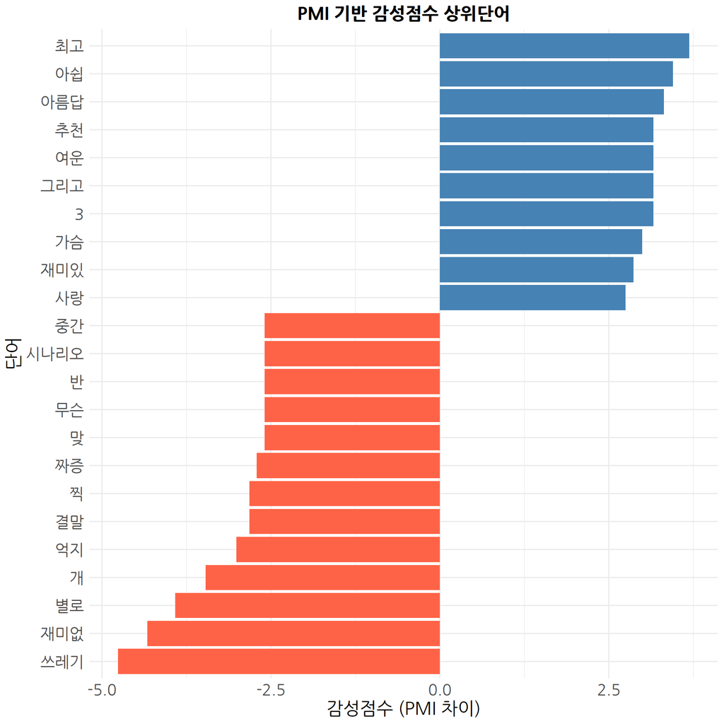

### 4) 새로운 영화 리뷰 최종 감성 예측하기

- 대상 데이터셋: NSMC 검증용 데이터셋(`data(movie_ratings_test)`).

#### A. 단계 1: **kiwipiepy**를 이용한 토큰화 함수 설정하기

```r
library(reticulate)
kiwi <- import("kiwipiepy")$Kiwi()

analyze_pos_kiwi <- function(text) {
  results <- kiwi$analyze(text)
  tagged_tokens <- map_dfr(results[[1]][[1]], ~tibble(
    morph = .x$form,
    pos = .x$tag
  ))
  stop_words_pos <- c("이/VCP", "것/NNB", "곳/NNG", "곳/NNB", "하/VX", "하/VV", "수/NNB", "되/VV",
                      "하/XSA", "들/XSN", "되/XSA", "되/XSV", "하/XSV", "이/VCP", "이/VV", "적/XSN")
  filtered_tokens <- tagged_tokens %>%
    filter(!str_detect(pos, "^J"),
           !str_detect(pos, "^E"),
           !str_detect(pos, "SF|SP|SS")
           ) %>%
    mutate(tagged_morph = str_c(morph, "/", pos)) %>%
    filter(!tagged_morph %in% stop_words_pos)

  return(list(tagged_morphs = filtered_tokens$tagged_morph))
}
```

#### B. 단계 2: NSMC 검증용 데이터셋 토큰화하기

##### a. 데이터셋 준비하기

```r
set.seed(123) # 난수 고정용.
library(bitNLP)
library(stringi)

movie_ratings_test_1000 <- sample_n(movie_ratings_test, size = 1000)
movie_ratings_test_tokenized <- movie_ratings_test_1000 %>%
  filter(document != "") %>%
  drop_na() %>%
  mutate(document = stri_enc_toutf8(document),
         document_tagged = map(document, analyze_pos_kiwi),
         document_tagged = map_chr(document_tagged, ~str_c(.x$tagged_morphs, collapse = " "))
         ) %>%
  mutate(morp = str_remove_all(document_tagged, "-[A-Z]{1,3}|/[A-Z]{1,3}"))
save(movie_ratings_test_tokenized, file= "movie_ratings_test_tokenized.rda")

# 분석 대상 데이터셋 파일 로드하기(현재 워킹 디렉토리에 안 떠 있을 경우에만).
load("movie_ratings_test_tokenized.rda")
load("sentiment_score.rda")
```

##### b. 총 감성점수 칼럼 생성하기

```r
movie_ratings_with_score <- movie_ratings_test_tokenized %>%
  mutate(
    # 1.  map_dbl을 사용해 morp 칼럼의 각 행 처리하기.
    total_senti_score = map_dbl(morp, ~ {

      # 2. morp 문자열을 공백을 기준으로 분리하여 단어 벡터 만들기.
      morp_words <- str_split(.x, " ")[[1]] # str_split 함수는 한 개의 항목으로 이뤄진 리스트를 반환하므로 해당 리스트의 첫 번째 항목(벡터 형식)만 취할 것을 명령.

      # 3. 감성점수 목록(sentiment_score) 티블에서 일치하는 단어만 필터링하고 감성점수 추출하기.
      matched_scores <- sentiment_score %>%
        filter(word %in% morp_words) %>% # 감성점수 티블의 단어 토큰 칼럼과 morp_words 토큰 벡터 중 일치하는 토큰만 골라내기.
        pull(score) # 감성점수 목록 티블의 score(감성점수) 항목만 벡터로 추출하기.

      # 4. 추출된 점수들을 모두 합산하기.
      sum(matched_scores)
    })
  ) %>%
  mutate(polarity = case_when(total_senti_score > 0 ~ 1, # 총 감성점수가 0보다 크면 극성을 1로 라벨링.
                                     T ~ 0), # 총 감성점수가 0보다 작으면 극성을 0으로 라벨링.
         total_senti_logical = case_when(polarity == label ~ T, # 새로 라벨링한 극성이 기존 극성과 일치하면 TRUE.
                                         polarity != label ~ F) # 새로 라벨링한 극성이 기존 극성과 일치하지 않으면 FALSE.
         )
movie_ratings_with_score
```

```
## # A tibble: 1,000 × 8
##    id
##    <chr>
##  1 9080718
##  2 6718145
##  3 8374538
##  4 534698
##  5 5121406
##  6 109213
##  7 6607368
##  8 455271
##  9 4354766
## 10 3974776
##    document
##    <chr>
```

[output cut: 59 more lines]

##### c. PMI 기반 감성분류의 정확도 계산하기

```r
movie_ratings_with_score %>%
  group_by(total_senti_logical) %>%  # 새로운 극성과 기존 극성의 일치 여부에 따라 그루핑.
  count() %>% # 빈도 계산.
  ungroup() %>% # 그루핑 해제.
  summarise(accuracy = n[2]/(n[1]+n[2])) # PMI 기반 극성 분류의 정확도 계산.
```

```
## # A tibble: 1 × 1
##   accuracy
##      <dbl>
## 1    0.761
```

## (4) 감정곡선(emotion curve) 생성하기

- 정의: 텍스트의 흐름 속에서 감성점수를 기반으로 시간적 또는 구조적 변화에 따라 감정의 기복을 시각화한 그래프.
- 방법
  - 단계 1: 텍스트를 단위별([EX] 문장, 단락, 시간순, 말 차례, 주제 등)로 나누기.
  - 단계 2: 각 단위에 단어들의 감성점수([EX] 감성사전 점수, PMI 감성점수 등)를 합산 또는 평균 내기.
  - 단계 3: 점수의 변화를 (꺾은)선 그래프로 표현하기. 이때 x축 = 텍스트 흐름([EX] 문장번호, 말 차례 번호 등), y축 = 감성점수.

### 1) 단계 1: 텍스트를 문장 단위로 나누기

```r
## 모두의 말뭉치 비출판물 텍스트(n=4)에 대해 KNU 감성사전을 기반으로 감정곡선 생성하기
load("sjml_result.rda")
library(bitNLP)
library(tidytext)
data(sentiment_dic) # KNU 감성사전 불러오기.

sjml_sample_step1 <- sjml_result %>%
  filter(title %in% c("일하기싫다", "나에게 쓰는 편지 ", "아내의 생일상", "졸업")) %>% # 300개 일기/수필 중에서 감정의 기복이 비교적 심한 텍스트 4개 추출하기.
  unnest_tokens(sentence, text, token = "sentences") %>% # unnest_tokens() 함수를 사용하여 text 칼럼의 텍스트를 문장 단위로 토큰화하기.
  group_by(title) %>% # 텍스트 제목을 기준으로 행들을 그루핑해주기.
  mutate(sentence_id = row_number()) # sentence_id(문장이 제시된 순서대로 번호가 매겨질 것)라는 칼럼을 만들어 개별 텍스트당 행 번호 넣기.
sjml_sample_step1
```

```
## # A tibble: 92 × 9
## # Groups:   title [4]
##    title         category        author_age author_occupation author_sex
##    <chr>         <chr>                <dbl> <chr>             <chr>
##  1 아내의 생일상 비출판물 > 수필         45 직장인/전문직     M
##  2 아내의 생일상 비출판물 > 수필         45 직장인/전문직     M
##  3 아내의 생일상 비출판물 > 수필         45 직장인/전문직     M
##  4 아내의 생일상 비출판물 > 수필         45 직장인/전문직     M
##  5 아내의 생일상 비출판물 > 수필         45 직장인/전문직     M
##  6 아내의 생일상 비출판물 > 수필         45 직장인/전문직     M
##  7 아내의 생일상 비출판물 > 수필         45 직장인/전문직     M
##  8 아내의 생일상 비출판물 > 수필         45 직장인/전문직     M
##  9 아내의 생일상 비출판물 > 수필         45 직장인/전문직     M
## 10 아내의 생일상 비출판물 > 수필         45 직장인/전문직     M
##    author_submission author_handwriting
```

[output cut: 36 more lines]